# Tarea-7

2023-09-26

# Lauro Reyes Rosas

## CU: 214532

### Graficas de cuantiles normales

Para las siguientes distribuciones toma una muestra de tamaño 1000 y realiza 1) una gráfica de cuantiles muestrales, 2) un histograma, 3) una gráfica de cuantiles normales:

- Log-normal(0, 2)

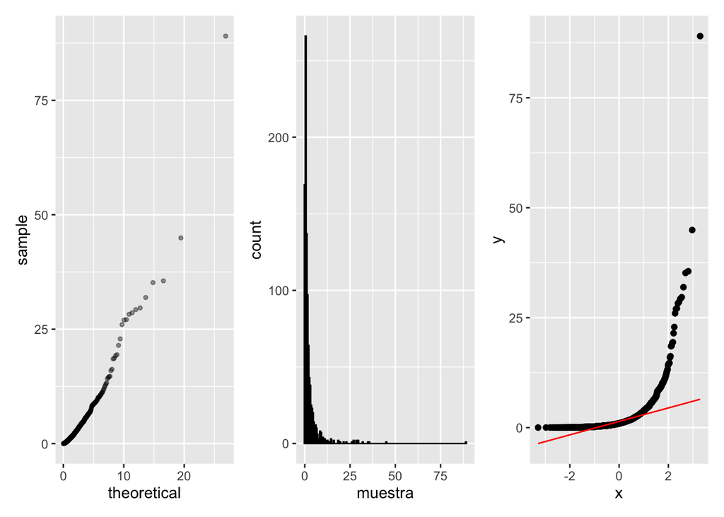

```r
set.seed(4)
# función de histograma y cuantiles normales
histograma <- function(muestra) {
  graf_2 <- ggplot(tibble(muestra), aes(x = muestra)) +
    geom_histogram(binwidth = 0.5, color = "black")

  graf_2
}

cuantiles_norm <- function(muestra) {
  graf_3 <- ggplot(tibble(muestra), aes(sample = muestra)) +
  geom_qq(distribution = stats::qnorm) +
  geom_qq_line(colour = "red")

  graf_3
}

muestra <- rlnorm(n = 1000, meanlog = 0, sdlog = sqrt(2))

graf_1 <- ggplot(data.frame(muestra), aes(sample = muestra)) +
  geom_qq(distribution = qlnorm, alpha = 0.4, size = 1)

graf_2 <- histograma(muestra)

graf_3 <- cuantiles_norm(muestra)

graf_1 + graf_2 + graf_3
```

- Gamma(2, 2)

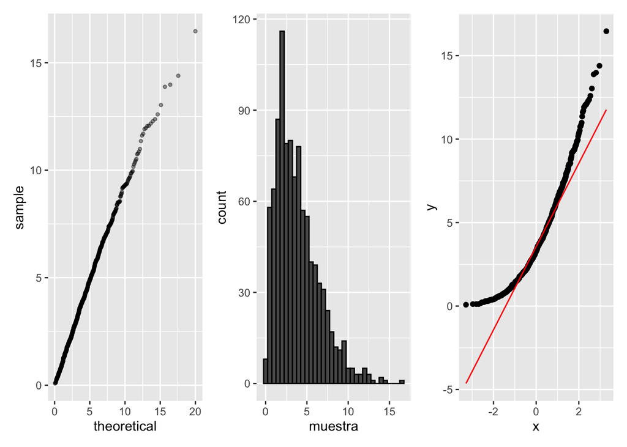

```r
muestra <- rgamma(n = 1000, shape = 2, scale = 2)

graf_1 <- ggplot(data.frame(muestra), aes(sample = muestra)) + geom_qq(distribution = qgamma, dparams = list(shape = 2, scale = 2), alpha = 0.4, size = 1)

graf_2 <- histograma(muestra)

graf_3 <- cuantiles_norm(muestra)

graf_1 + graf_2 + graf_3
```

- Student-t con 1 grado de libertad

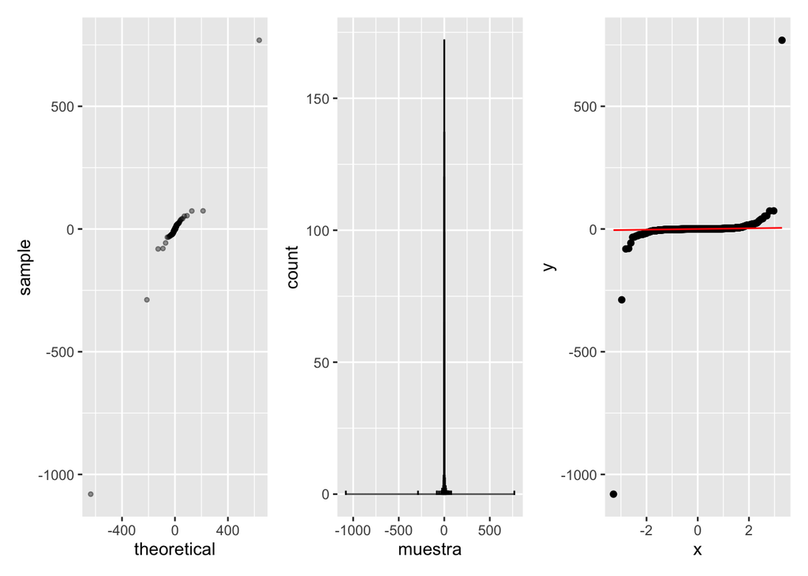

```r
muestra <- rt(n = 1000, df = 1)

graf_1 <- ggplot(data.frame(muestra), aes(sample = muestra)) +
  geom_qq(distribution = qt, dparams = list(df = 1), alpha = 0.4, size = 1)

graf_2 <- histograma(muestra)

graf_3 <- cuantiles_norm(muestra)

graf_1 + graf_2 + graf_3
```

- Student-t con 10 grado de libertas

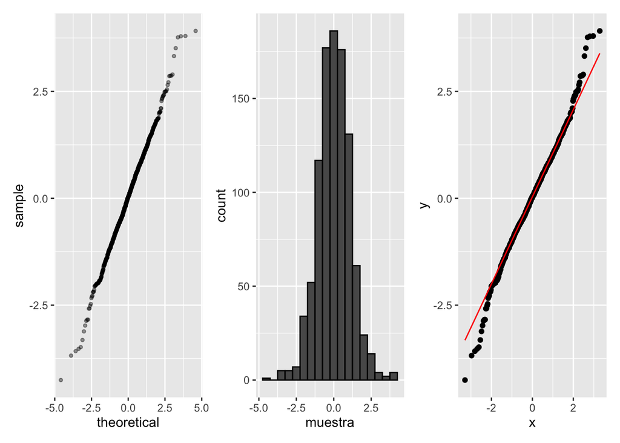

```r
muestra <- rt(n = 1000, df = 10)
graf_1 <- ggplot(data.frame(muestra), aes(sample = muestra)) + geom_qq(distribution = qt, dparams = list(df = 10), alpha = 0.4, size = 1)

graf_2 <- histograma(muestra)

graf_3 <- cuantiles_norm(muestra)

graf_1 + graf_2 + graf_3
```

### Bootstrap

1. Se realiza un experimento en el que se seleccionan 7 ratones de manera aleatoria de un total de 16 ratones. A los siete seleccionados se les suministra un tratamiento mientras que los restantes formarán el grupo de control. El objetivo del tratamiento es prolongar la supervivencia de los ratones. La siguiente tabla muestra el tiempo de supervivencia en días después de suministrar el tratamiento.

| Grupo | Datos | Tamaño de muestra |
| --- | --- | --- |
| Tratamiento | 94, 197, 16, 38, 99, 141, 23 | 7 |
| Control | 52, 104, 146, 10, 51, 30, 40, 27, 46 | 9 |

1. Usa las medias de las muestras para determinar si hay diferencias en los grupos, esto es calcula $\bar{x}-\bar{y}$.

```r
x <- c(94, 197, 16, 38, 99, 141, 23)
y = c(52, 104, 146, 10, 51, 30, 40, 27, 46)
mean(x) - mean(y)
```

```
## [1] 30.63492
```

2. Estima el error estándar de la diferencia usando bootsrap.

```r
N = length(x) + length(y)
# Bootstrap
B = 1000

Media_boot <- replicate(B, {
  sample_x <- sample(x, length(x), replace = TRUE)
  sample_y <- sample(y, length(y), replace = TRUE)
  mean(sample_x) - mean(sample_y)
})

ee_boot_diferencia_medias <- sd(Media_boot)
media_diferencia_medias <- mean(Media_boot)

sprintf("Error Estandar diferencia de medias %s & Media de diferencias de medias %s.",
        ee_boot_diferencia_medias, media_diferencia_medias)
```

```
## [1] "Error Estandar diferencia de medias 27.8255300361646 & Media de diferencias de medias 30.1715079365079."
```

```r
Median_boot <- replicate(B, {
  sample_x <- sample(x, length(x), replace = TRUE)
  sample_y <- sample(y, length(y), replace = TRUE)
  median(sample_x) - median(sample_y)
})

ee_boot_diferencia_medianas <- sd(Median_boot)
media_diferencia_medianas <- mean(Median_boot)

sprintf("Error Estandar diferencia de medianas %s & Media de diferencias de medianas %s.",
        ee_boot_diferencia_medianas, media_diferencia_medianas)
```

```
## [1] "Error Estandar diferencia de medianas 40.1207708332262 & Media de diferencias de medianas 34.368."
```

5. **Bootstrap correlación.** Nuevamente trabaja con los datos `primaria`, selecciona una muestra aleatoria de tamaño $100$ y utiliza el principio del *plug-in* para estimar la correlación entre la calificación de $y=$español $3$ y la de $z=$español $6$: $\hat{corr}(y,z)$. Usa bootstrap para calcular el error estándar de la estimación.

```r
x = enlace$esp_3
y = enlace$esp_6

Cor_boot <- replicate(B, {
  sample_x <- sample(x, length(x), replace = TRUE)
  sample_y <- sample(y, length(y), replace = TRUE)
  cor(sample_x,sample_y)
})
print(ee_boot_correlacion <- sd(Cor_boot))
```

```
## [1] 0.01172395
```